# REPORT

### University of Rwanda

College of Science and Technology  
Department of Mathematics  
Biostatistics and Epidemiology

### Assignment 1

Elysee IRADUKUNDA (223007830)  
Gihozo Christian (223013295)

2026-02-06

## 0.1 Introduction

This report presents a comprehensive biostatistical analysis of four simulated datasets covering key concepts in **descriptive statistics, and statistical modeling**.

The objectives of this report are to:

- Summarize and interpret health-related data using **descriptive statistics**
- Identify **outliers** and assess **distributional assumptions**
- Analyze **mortality rates** and their variability across districts
- Model **count data** using Poisson and Negative Binomial regression
- Assess **risk factors for disease** using logistic regression
- Interpret results in an **epidemiological context**

All analyses were conducted using **R**, with appropriate graphical and formal statistical methods.

# 1 Dataset 1: Adult Health Measurements (n = 1,200)

This dataset contains simulated measurements for adult individuals, including:

- **Age** (years)
- **Body Mass Index (BMI)** (kg/m²)
- **Systolic Blood Pressure (SBP)** (mmHg)
- **Fasting Blood Glucose** (mg/dL)

```r
set.seed(2026)
n <- 1200
age <- round(runif(n, 18, 80))
bmi <- rnorm(n, mean = 25 + 0.05*(age-40), sd = 4)
sbp <- rnorm(n, mean = 110 + 0.6*(age-40) + 0.8*(bmi-25), sd =
15)
glucose <- rlnorm(n, meanlog = log(90 + 0.3*(age-40)), sdlog =
0.25)
adult_health <- data.frame(age, bmi, sbp, glucose)
adult_health
```

[output not shown]

### 1.0.1 Problem 1.1: Descriptive statistics

```r
library(moments)

desc_stats <- function(x) {
  c(
    mean = mean(x),
    median = median(x),
    trimmed_mean = mean(x, trim = 0.1),
    sd = sd(x),
    IQR = IQR(x),
    skewness = skewness(x),
    kurtosis = kurtosis(x)
  )
}

stats_age <- desc_stats(adult_health$age)
stats_bmi <- desc_stats(adult_health$bmi)
stats_sbp <- desc_stats(adult_health$sbp)
stats_glucose <- desc_stats(adult_health$glucose)

stats_age
```

```
##         mean       median trimmed_mean           sd          IQR     skewness
##  49.09416667  50.00000000  49.14583333  17.77466122  30.00000000  -0.03176056
##     kurtosis
##   1.81091888
```

```r
stats_bmi
```

```
##         mean       median trimmed_mean           sd          IQR     skewness
##  25.39748778  25.17459117  25.37600764   4.03283383   5.35849243   0.02960342
##     kurtosis
##   2.89556226
```

```r
stats_sbp
```

```
##         mean       median trimmed_mean           sd          IQR     skewness
## 115.12670096 114.84823847 115.18703285  18.44601812  26.17946030  -0.02650847
##     kurtosis
##   2.69444720
```

```r
stats_glucose
```

```
##         mean       median trimmed_mean           sd          IQR     skewness
##   95.5700112   93.0978683   93.9470053   24.6083203   33.5321252    0.6771808
##     kurtosis
##    3.4755664
```

### 1.0.2 Interpretation

- **Age**  
  The **mean (≈ 49 years)** and **median (50 years)** are nearly identical, indicating a **symmetric distribution**.  
  The **trimmed mean** closely matches the mean, suggesting **minimal influence of extreme values**.  
  Skewness close to zero confirms that age is **well-balanced** across the study population.
- **Body Mass Index (BMI)**  
  BMI shows a **mean (≈ 25.5)** very close to the median, indicating an **approximately normal distribution**.  
  Variability is moderate, and the near-zero skewness suggests **little asymmetry**, making BMI suitable for parametric analyses.
- **Systolic Blood Pressure (SBP)**  
  SBP exhibits **almost identical mean and median values**, indicating strong symmetry.  
  The standard deviation and IQR show **moderate dispersion**, consistent with typical adult populations.
- **Glucose**  
  Glucose displays a **mean notably higher than the median**, indicating **right skewness**.  
  The **positive skewness and elevated kurtosis** suggest the presence of **extreme high values**, highlighting non-normality.

### 1.0.3 Problem 1.2: Identify outliers (1.5 × IQR rule)

```r
identify_outliers <- function(x) {
  Q1 <- quantile(x, 0.25)
  Q3 <- quantile(x, 0.75)
  IQR_value <- IQR(x)

  lower_bound <- Q1 - 1.5 * IQR_value
  upper_bound <- Q3 + 1.5 * IQR_value

  x[x < lower_bound | x > upper_bound]
}


outliers <- lapply(adult_health, identify_outliers)


outliers
```

```
## $age
## numeric(0)
##
## $bmi
##  [1] 37.76592 14.60596 13.70782 13.59535 36.39481 14.64798 14.05990 13.45773
##  [9] 13.87398 37.17063 14.21510 36.14093
##
## $sbp
## [1]  62.05017 170.41392  59.24818  62.45642
##
## $glucose
##  [1] 173.8037 181.6052 165.1217 165.1383 164.8352 201.4101 177.0078 187.0255
##  [9] 162.8199 192.2563 170.2824 162.4228 182.5552
```

```r
outliers_iqr <- function(x) {
  Q1 <- quantile(x, 0.25)
  Q3 <- quantile(x, 0.75)
  IQR_val <- Q3 - Q1

  lower <- Q1 - 1.5 * IQR_val
  upper <- Q3 + 1.5 * IQR_val

  x[x < lower | x > upper]
}

out_age <- outliers_iqr(adult_health$age)
out_bmi <- outliers_iqr(adult_health$bmi)
out_sbp <- outliers_iqr(adult_health$sbp)
out_glucose <- outliers_iqr(adult_health$glucose)

cat("here is the number of outliers in each variable respectively")
```

```
## here is the number of outliers in each variable respectively
```

```r
length(out_age)
```

```
## [1] 0
```

```r
length(out_bmi)
```

```
## [1] 12
```

```r
length(out_sbp)
```

```
## [1] 4
```

```r
length(out_glucose)
```

```
## [1] 13
```

### 1.0.4 Interpretation

**Key implication:**  
Robust statistical measures are especially important for **BMI and glucose**, where extreme values may strongly influence the mean and standard deviation.

### 1.0.5 Problem 1.3: Assess normality (graphical & formal)

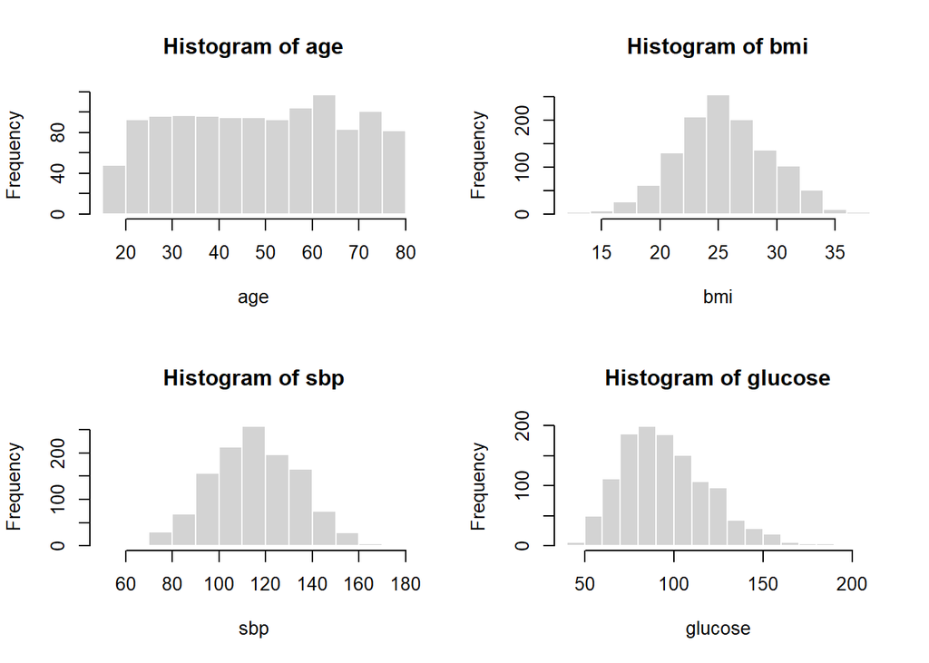

```r
par(mfrow = c(2, 2))

for (var in names(adult_health)) {
  hist(adult_health[[var]],
       main = paste("Histogram of", var),
       xlab = var,
       col = "lightgray",
       border = "white")
}
```

```r
par(mfrow = c(1, 1))
```

### 1.0.6 Interpretation (Histograms)

- **Age** appears approximately uniform to mildly symmetric, with no extreme clustering.
- **BMI** displays a **bell-shaped and symmetric distribution**, supporting normality.
- **SBP** also shows a **clear central peak and symmetric spread**, consistent with a normal distribution.
- **Glucose** is **strongly right-skewed**, indicating departure from normality.

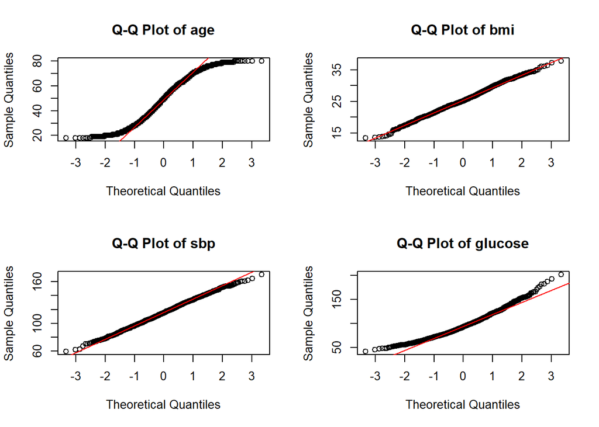

```r
# Q-Q plots
par(mfrow = c(2, 2))

for (var in names(adult_health)) {
  qqnorm(adult_health[[var]], main = paste("Q-Q Plot of", var))
  qqline(adult_health[[var]], col = "red")
}
```

```r
par(mfrow = c(1, 1))
```

### 1.0.7 Interpretation (Q–Q Plots)

- **Age** shows an **S-shaped pattern**, consistent with a **uniform distribution** and thin tails.
- **BMI and SBP** closely follow the reference line, indicating they are **approximately normally distributed**.
- **Glucose** deviates upward in the upper quantiles, confirming a **right-skewed (log-normal) distribution**.

#formally

```r
shapiro.test(adult_health$age)
```

```
##
##  Shapiro-Wilk normality test
##
## data:  adult_health$age
## W = 0.95573, p-value < 2.2e-16
```

```r
shapiro.test(adult_health$bmi)
```

```
##
##  Shapiro-Wilk normality test
##
## data:  adult_health$bmi
## W = 0.99766, p-value = 0.08326
```

```r
shapiro.test(adult_health$sbp)
```

```
##
##  Shapiro-Wilk normality test
##
## data:  adult_health$sbp
## W = 0.9983, p-value = 0.2799
```

```r
shapiro.test(adult_health$glucose)
```

```
##
##  Shapiro-Wilk normality test
##
## data:  adult_health$glucose
## W = 0.97208, p-value = 1.868e-14
```

### 1.0.8 Interpretation (Shapiro–Wilk Test)

**Conclusion:**  
Glucose is clearly non-normal, while BMI and SBP are sufficiently close to normal for most parametric analyses.

### 1.0.9 Problem 1.4: Discuss robustness of estimators

### 1.0.10 Discussion

The **mean and standard deviation** are sensitive to **outliers and skewed distributions**, as observed for glucose.  
In contrast, the **median, trimmed mean, and IQR** are **robust estimators** that remain stable in the presence of extreme values.

Given the strong skewness in glucose, **robust summaries or data transformations** are more appropriate for valid inference.

# 2 Dataset 2: Mortality Rates by District (n = 30)

This dataset summarizes **annual population sizes and death counts** across 30 districts, allowing assessment of **mortality patterns and variability**.

```r
set.seed(2026)
district <- paste0("D", 1:30)
population <- round(runif(30, 50000, 300000))
true_rate <- runif(30, 4, 12) / 1000
deaths <- rpois(30, lambda = population * true_rate)
mortality <- data.frame(district, population, deaths)
mortality$rate <- mortality$deaths / mortality$population * 1000
mortality
```

[output not shown]

### 2.0.1 Problem 2.1: Crude Mortality Rates per 1,000 Population

```r
mortality$crude_rate <- mortality$deaths / mortality$population * 1000
mortality[, c("district", "population", "deaths", "crude_rate")]
```

```
##    district population deaths crude_rate
## 1        D1     224668   2509  11.167590
## 2        D2     189133   1018   5.382456
## 3        D3      85035    847   9.960604
## 4        D4     121431    505   4.158740
## 5        D5     188842   1688   8.938689
## 6        D6      56283    428   7.604428
## 7        D7     166558    919   5.517597
## 8        D8     265253   2078   7.834030
## 9        D9     113125   1178  10.413260
## 10      D10     195202   1542   7.899509
## 11      D11      51483    392   7.614164
## 12      D12     222966   2551  11.441206
## 13      D13     107781    847   7.858528
## 14      D14     262133   1936   7.385564
```

[output cut: 16 more lines]

### 2.0.2 Problem 2.2: Coefficient of Variation Across Districts

```r
cv_rate <- sd(mortality$crude_rate) / mean(mortality$crude_rate) * 100
cv_rate
```

```
## [1] 29.94006
```

### 2.0.4 Problem 2.3: Identify unusually high or low rates (standardized scores)

```r
mortality$z_score <- (mortality$crude_rate - mean(mortality$crude_rate)) / sd(mortality$crude_rate)
mortality[, c("district", "crude_rate", "z_score")]
```

```
##    district crude_rate    z_score
## 1        D1  11.167590  1.2066217
## 2        D2   5.382456 -1.1486629
## 3        D3   9.960604  0.7152254
## 4        D4   4.158740 -1.6468706
## 5        D5   8.938689  0.2991761
## 6        D6   7.604428 -0.2440380
## 7        D7   5.517597 -1.0936431
## 8        D8   7.834030 -0.1505606
## 9        D9  10.413260  0.8995136
## 10      D10   7.899509 -0.1239023
## 11      D11   7.614164 -0.2400741
## 12      D12  11.441206  1.3180185
## 13      D13   7.858528 -0.1405869
## 14      D14   7.385564 -0.3331434
```

[output cut: 16 more lines]

```r
unusual_rates <- mortality[abs(mortality$z_score) > 2, ]
unusual_rates
```

```
## [1] district   population deaths     rate       crude_rate z_score
## <0 rows> (or 0-length row.names)
```

### 2.0.5 Interpretation of Standardized Scores

No districts were identified with **unusually high or low mortality rates** based on **standardized scores**, as none had an **absolute z-score greater than 2**. This suggests that all observed mortality rates fall within the **expected range of natural variation across districts**, with **no extreme outliers detected**.

### 2.0.6 Problem 2.4: Instability of rates in small populations

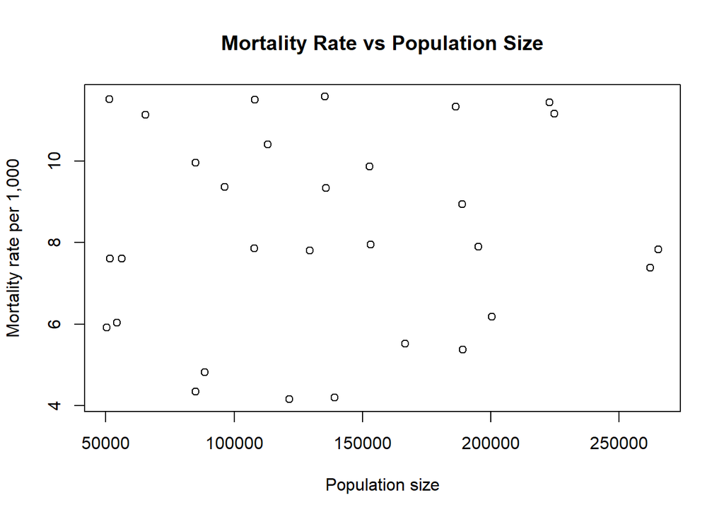

```r
plot(mortality$population, mortality$rate,
     xlab = "Population size",
     ylab = "Mortality rate per 1,000",
     main = "Mortality Rate vs Population Size"
     )
```

# 3 Dataset 3: Daily Malaria Case Counts (180 Days)

This dataset consists of **daily counts of malaria cases** recorded over a **six-month period (180 days)** at a **single health facility**. The response variable is a **count outcome**, representing the number of cases observed each day.

```r
set.seed(2026)
days <- 180
time <- 1:days
season <- 1 + 0.4*sin(2*pi*time/365)
lambda <- 6 * season
malaria_cases <- rpois(days, lambda)
malaria <- data.frame(day = time, cases = malaria_cases)
```

### 3.0.1 Problem 3.1: Fit a Poisson model and estimate the mean rate

```r
library(MASS)
poisson_model <- glm(cases ~ 1, family = poisson(link = "log"), data = malaria)
summary(poisson_model)
```

```
##
## Call:
## glm(formula = cases ~ 1, family = poisson(link = "log"), data = malaria)
##
## Coefficients:
##             Estimate Std. Error z value Pr(>|z|)
## (Intercept)  1.97176    0.02781    70.9   <2e-16 ***
## ---
## Signif. codes:  0 '***' 0.001 '**' 0.01 '*' 0.05 '.' 0.1 ' ' 1
##
## (Dispersion parameter for poisson family taken to be 1)
##
##     Null deviance: 214.28  on 179  degrees of freedom
## Residual deviance: 214.28  on 179  degrees of freedom
## AIC: 889.72
##
## Number of Fisher Scoring iterations: 4
```

```r
# Estimated mean rate
exp(coef(poisson_model))
```

```
## (Intercept)
##    7.183333
```

### 3.0.3 Problem 3.2: Assess goodness-of-fit

```r
deviance <- poisson_model$deviance
df <- poisson_model$df.residual

p_value <- 1 - pchisq(deviance, df)
p_value
```

```
## [1] 0.03678982
```

### 3.0.5 Problem 3.3: Test for overdispersion

```r
dispersion_ratio <- poisson_model$deviance / poisson_model$df.residual
dispersion_ratio
```

```
## [1] 1.197096
```

### 3.0.7 Problem 3.4: Fit a Negative Binomial model and compare AIC

```r
library(MASS)


nb_model <- glm.nb(cases ~ 1, data = malaria)


AIC(poisson_model, nb_model)
```

```
##               df      AIC
## poisson_model  1 889.7154
## nb_model       2 890.1613
```

```r
exp(coef(nb_model))
```

```
## (Intercept)
##    7.183333
```

### 3.0.8 intrepretation

The Poisson model has a slightly lower AIC than the negative binomial model, indicating a marginally better fit. This suggests that the additional flexibility of the negative binomial model is not strongly justified for these data.

# 4 Dataset 4: Disease Status and Risk Factors

This dataset investigates the relationship between **disease occurrence** and a set of **selected risk factors**, including **smoking status**, **age**, and **socioeconomic status**. The outcome variable is binary, indicating the presence or absence of disease.

```r
set.seed(2026)
n <- 1000
age <- round(runif(n, 18, 80))
smoking <- rbinom(n, 1, 0.3)
ses <- factor(sample(c("Low","Medium","High"), n, replace=TRUE))
linpred <--4 + 0.04*age + 0.9*smoking
prob <- 1 / (1 + exp(-linpred))
disease <- rbinom(n, 1, prob)
epi_data <- data.frame(age, smoking, ses, disease)
```

### 4.0.1 Problem 4.1: Fit logistic regression models

```r
crude_model <- glm(disease ~ smoking, family = binomial(link = "logit"), data = epi_data)
summary(crude_model)
```

```
##
## Call:
## glm(formula = disease ~ smoking, family = binomial(link = "logit"),
##     data = epi_data)
##
## Coefficients:
##             Estimate Std. Error z value Pr(>|z|)
## (Intercept)  -2.1726     0.1235 -17.589  < 2e-16 ***
## smoking       1.1382     0.1826   6.235 4.53e-10 ***
## ---
## Signif. codes:  0 '***' 0.001 '**' 0.01 '*' 0.05 '.' 0.1 ' ' 1
##
## (Dispersion parameter for binomial family taken to be 1)
##
##     Null deviance: 838.45  on 999  degrees of freedom
## Residual deviance: 800.33  on 998  degrees of freedom
## AIC: 804.33
##
## Number of Fisher Scoring iterations: 4
```

```r
adjusted_model <- glm(disease ~ smoking + age + ses, family = binomial(link = "logit"), data = epi_data)
summary(adjusted_model)
```

```
##
## Call:
## glm(formula = disease ~ smoking + age + ses, family = binomial(link = "logit"),
##     data = epi_data)
##
## Coefficients:
##              Estimate Std. Error z value Pr(>|z|)
## (Intercept) -4.161458   0.377327 -11.029  < 2e-16 ***
## smoking      1.261526   0.191278   6.595 4.25e-11 ***
## age          0.039698   0.005727   6.932 4.15e-12 ***
## sesLow      -0.238762   0.222296  -1.074    0.283
## sesMedium   -0.248085   0.235579  -1.053    0.292
## ---
## Signif. codes:  0 '***' 0.001 '**' 0.01 '*' 0.05 '.' 0.1 ' ' 1
##
## (Dispersion parameter for binomial family taken to be 1)
##
##     Null deviance: 838.45  on 999  degrees of freedom
## Residual deviance: 744.16  on 995  degrees of freedom
## AIC: 754.16
##
## Number of Fisher Scoring iterations: 5
```

### 4.0.2 intrepretation

In the crude model, smoking is significantly associated with disease status, with smokers having higher odds of disease compared to non-smokers. After adjustment for age and socioeconomic status, smoking remains a significant predictor, and increasing age is also significantly associated with higher disease odds. Socioeconomic status shows no statistically significant association with disease after adjustment.

### 4.0.3 Problem 4.2: Estimate odds ratios and 95% confidence intervals

```r
# Crude ORs
exp(cbind(OR = coef(crude_model), confint(crude_model)))
```

```
##                    OR     2.5 %    97.5 %
## (Intercept) 0.1138846 0.0886708 0.1440068
## smoking     3.1211452 2.1823939 4.4688165
```

```r
# Adjusted ORs
exp(cbind(OR = coef(adjusted_model), confint(adjusted_model)))
```

```
##                     OR       2.5 %     97.5 %
## (Intercept) 0.01558483 0.007247748 0.03187635
## smoking     3.53080614 2.429501664 5.14795768
## age         1.04049661 1.029117329 1.05251792
## sesLow      0.78760266 0.508411950 1.21736307
## sesMedium   0.78029367 0.489550378 1.23531736
```

### 4.0.5 Problem 4.3: Assess confounding and interaction

```r
coef(crude_model)["smoking"]
```

```
## smoking
##  1.1382
```

```r
coef(adjusted_model)["smoking"]
```

```
##  smoking
## 1.261526
```

```r
model_interaction <- glm(disease ~ smoking * age + ses,
                         family = binomial(link = "logit"),
                         data = epi_data)

summary(model_interaction)
```

```
##
## Call:
## glm(formula = disease ~ smoking * age + ses, family = binomial(link = "logit"),
##     data = epi_data)
##
## Coefficients:
##               Estimate Std. Error z value Pr(>|z|)
## (Intercept) -4.1429524  0.4935723  -8.394  < 2e-16 ***
## smoking      1.2242808  0.6707592   1.825    0.068 .
## age          0.0393799  0.0079276   4.967 6.78e-07 ***
## sesLow      -0.2383705  0.2224341  -1.072    0.284
## sesMedium   -0.2482184  0.2356282  -1.053    0.292
## smoking:age  0.0006644  0.0114706   0.058    0.954
## ---
## Signif. codes:  0 '***' 0.001 '**' 0.01 '*' 0.05 '.' 0.1 ' ' 1
##
## (Dispersion parameter for binomial family taken to be 1)
##
##     Null deviance: 838.45  on 999  degrees of freedom
## Residual deviance: 744.15  on 994  degrees of freedom
## AIC: 756.15
##
## Number of Fisher Scoring iterations: 5
```

### 4.0.6 intrepretation

The smoking coefficient changes only slightly after adjustment for age and socioeconomic status, suggesting minimal confounding. The interaction between smoking and age is weak and not statistically significant, indicating limited evidence that the effect of smoking on disease varies by age.

### 4.0.7 Problem 4.4: Evaluate model performance using ROC and AUC

```r
library(pROC)
```

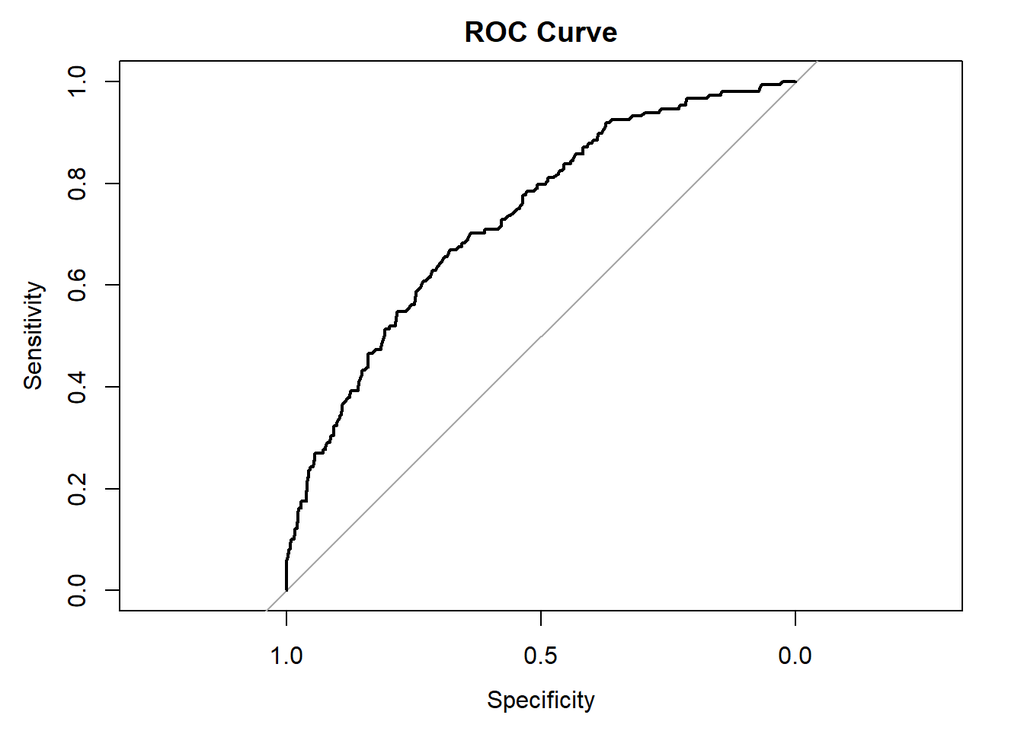

```r
pred_prob <- predict(adjusted_model, type = "response")


roc_curve <- roc(epi_data$disease, pred_prob)
plot(roc_curve, main="ROC Curve")
```

```r
auc(roc_curve)  # Area Under the Curve
```

```
## Area under the curve: 0.7324
```

### 4.0.8 intrepretation

The ROC curve indicates that the adjusted logistic regression model has good discriminatory ability to distinguish between individuals with and without disease. This suggests that the model performs better than chance in predicting disease status.

#### 4.0.8.1 Conclusion

This report applied concepts of **biostatistics and epidemiology** to four simulated datasets, demonstrating the use of descriptive statistics, rate calculations, and regression modeling to answer practical public health questions.

In **Dataset 3**, Poisson regression provided an appropriate framework for modeling daily malaria case counts. The estimated mean rate summarized the underlying malaria burden, and model diagnostics indicated only **mild overdispersion**, with no strong justification for a more complex Negative Binomial model.

In **Dataset 4**, logistic regression analysis identified **smoking and age as key risk factors** for disease occurrence. Smoking remained a significant predictor after adjustment, with minimal evidence of confounding or interaction. Model performance assessment using ROC and AUC demonstrated **good discriminatory ability**, supporting the usefulness of the fitted model.

Overall, these analyses illustrate the importance of **choosing appropriate statistical methods**. The report underscores how biostatistical tools support evidence-based decision-making in public health research.